### TEL101 - Iniciación a la Programación

# Clase 4: Strings

Prof. Nicolás Torres  
nicolas.torresr@usm.cl  
Ingeniería Civil Telemática  
Departamento de Electrónica  
Universidad Técnica Federico Santa María

# Strings

Cadenas de texto que se definen entre comillas simples `‘’` o dobles `“ ”`.

```python
mensaje = 'Hola Mundo'
saludo = "Hello World"
```

# Caracteres especiales

Python posee caracteres especiales que interpreta dentro de los strings. El carácter de barra invertida o *backslash* (`\`), se usa como carácter de escape para producir efectos especiales en los textos como agregar una nueva línea o una tabulación.

```python
x = 'blanco\nazul\nrojo'
print(x)
```

```
blanco
azul
rojo
```

```python
print("blanco\tazul\trojo\nverde\tlila\tgris")
```

```
blanco	azul	rojo
verde	lila	gris
```

# Indexación

Una cadena de caracteres tiene elementos ordenados posicionalmente. Por lo tanto, cada carácter dentro del texto puede ser enumerado individualmente.

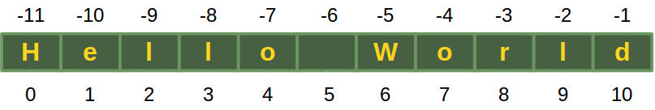

## Acceso

Es posible acceder a cualquier caracter de la secuencia a través de su índice usando el operador corchete `[]`.

```python
vocales = "aeiou"
```

```python
vocales[0]
```

```
'a'
```

```python
vocales[-1]
```

```
'u'
```

# Inmutabilidad

Los strings son secuencias **inmutables** de caracteres, es decir, sus elementos no pueden ser modificados.

```python
vocales[0] = "f"
```

```
---------------------------------------------------------------------------
TypeError                                 Traceback (most recent call last)
Input In [7], in <cell line: 1>()
----> 1 vocales[0] = "f"

TypeError: 'str' object does not support item assignment
```

## Rebanada (Slicing)

`s[i:j]`, entrega los caracteres comenzando en la posición `i` hasta el carácter en la posición `j-1` del string `s`.

```python
vocales[1:4]
```

```
'eio'
```

`s[i:]` entrega los elementos desde el índice `i` hasta el final.

```python
vocales[2:]
```

```
'iou'
```

`s[:j]` entrega los elementos desde el inicio hasta el índice `j-1`.

```python
vocales[:3]
```

```
'aei'
```

`s[i:j:k]`, entrega los caracteres comenzando en la posición `i` hasta el carácter en la posición `j-1` con salto o incremento de `k`.

```python
vocales[1:4:2]
```

```
'eo'
```

# Operaciones elementales sobre strings

## Concatenación

El operador concatenador (`+`) retorna la unión entre secuencias.

```python
'a' + 'b' + 'c'
```

```
'abc'
```

```python
'1' + '2'
```

```
'12'
```

## Repetición

El operador repetidor (`*`) retorna los elementos de la secuencia repetidos.

```python
'na ' * 5
```

```
'na na na na na '
```

## Membresía

Los operadores de **membresía** o **pertenencia** (`in` y `not in`) evalúan si un valor es miembro de otro. En otras palabras, permiten saber si un elemento está contenido en una secuencia. En los strings, `x in y` es `True` si y solo si `x` es un substring de `y`.

```python
'pollo' in 'repollo'
```

```
True
```

```python
'pollo' in 'rechicken'
```

```
False
```

# Funciones básicas sobre strings

## Longitud de un string

La función `len(s)` retorna el número de caracteres en el string `s`.

```python
len("hola mundo")
```

```
10
```

```python
len('')
```

```
0
```

```python
len('a\nb')
```

```
3
```

## Mínimo y Máximo

La función `min(s)` retorna el menor carácter en el string `s`.

La función `max(s)` retorna el mayor carácter en el string `s`.

El criterio que utiliza para comparar caracteres es el **orden lexicográfico**.

```python
min('aeiou')
```

```
'a'
```

```python
max('aeiou')
```

```
'u'
```

# Métodos

- Un método es una función que «pertenece a» un tipo de dato.
- Un método se llama por su nombre, pero está asociado a un tipo de dato y puede o no retornar un valor.
- Para utilizar los métodos en Python la sintaxis es: el dato, seguido de punto y el método que se desea utilizar.

Entonces, **¿Cuál es la diferencia entre métodos y funciones?.**

- La principal diferencia es que un método es parte de las propiedades de un tipo de dato específico.
- Cada tipo de dato tiene sus propios métodos. Incluso aunque se llamen igual, pueden tener un comportamiento distinto.
- En cambio, las funciones son entidades independientes en un programa.

# Métodos básicos de los strings

Los strings tienen muchos métodos, pero por ahora, nos enfocaremos en los más básicos para entender su funcionamiento.

## Mayúsculas y Minúsculas

El método `str.lower()` retorna una copia del string `str` con todos sus caracteres en minúsculas.

El método `str.upper()` retorna una copia del string `str` con todos sus caracteres en mayúsculas.

```python
x = "Hola Mundo"

print(x.upper())
print(x.lower())
```

```
HOLA MUNDO
hola mundo
```

Ambos métodos retornan una copia del string, no modifican los caracteres del string original.

```python
mayusculas = x.upper()
minusculas = x.lower()
```

```python
print(mayusculas)
print(minusculas)
print(x)
```

```
HOLA MUNDO
hola mundo
Hola Mundo
```

## Método `find`

El método `str.find(s)` retorna el índice más bajo donde se encuentra el substring `s` en el string `str`. Si no se encuentra, retorna `-1`.

```python
"abracadabra".find("a")
```

```
0
```

```python
"abracadabra".find("e")
```

```
-1
```

## Método `count`

El método `str.count(s)` retorna el número de ocurrencias del substring `s` en el string `str`.

```python
"abracadabra".count("a")
```

```
5
```

```python
"abracadabra".count("e")
```

```
0
```

# Iterable

Los strings son **iterables**, es decir, se pueden recorrer elemento por elemento, a través de un ciclo.

# Estructura de Repetición `for`

- Funciona sobre tipos de datos **iterables**.
- Recorre secuencias finitas. Por lo tanto, itera una cantidad **fija** de veces.

### Sintaxis genérica de un ciclo `for`

```
for variable in secuencia:
    sentencias para cada elemento de la secuencia
```

- Cada vez que se utiliza un ciclo `for`, se define automáticamente una `variable` cuyo valor será cada uno de los elementos de la `secuencia`, en orden, uno por uno.
- La `secuencia` debe ser un tipo de dato **iterable** (Por ejemplo, un string o una lista).
- No confundir el "`in`" que se utiliza en el `for` con el operador para verificar membresía.

### Ejemplo

```python
vocales = "aeiou"
for letra in vocales:
    print(letra)
```

```
a
e
i
o
u
```

La variable `letra` de forma automática va iterando sobre cada caracter del texto.

### Equivalencia entre ciclo `while` y ciclo `for`.

El ciclo `while` también se puede utilizar para recorrer una secuencia. Sin embargo, no itera sobre los elementos de forma automática como el `for`.

```python
vocales = "aeiou"
i = 0
while i < len(vocales):
    letra = vocales[i]
    print(letra)
    i += 1
```

```
a
e
i
o
u
```